# PA1 template 3

Sharon 1

January 17, 2017

## Loading and preprocessing the data

Reading in the data file and only keep non-missing records

```r
setwd("C:/Users/sharon.liu/Documents/R/course 5/")
outdir<- getwd()
if (!require("ggplot2")) {
  install.packages("ggplot2", repos="http://cran.rstudio.com/")
  library("ggplot2")
}
if (!require("scales")) {
  install.packages("scales", repos="http://cran.rstudio.com/")
  library("scales")
}
if (!require("Hmisc")) {
  install.packages("Hmisc", repos="http://cran.rstudio.com/")
  library("Hmisc")
}
steps<-read.csv("activity.csv",header=TRUE, sep=",")
steps_notna<-subset(steps, !is.na(steps))
```

Calculate the total number of steps taken per day.

```r
steps_day<-aggregate(steps[1],by=steps[2],FUN=sum, na.rm=TRUE)
```

Create a histogram of the results

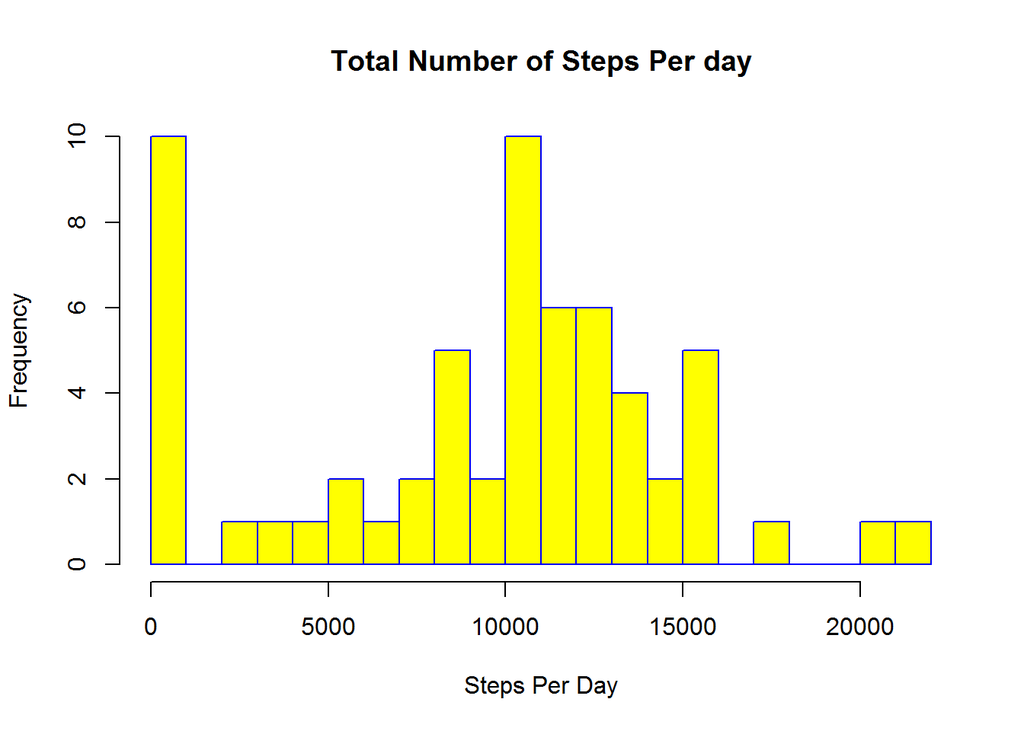

```r
hist(steps_day$steps,breaks=20, col="yellow", main="Total Number of Steps Per day", xlab="Steps Per Day", border="blue")
```

Calculate and report the mean of the total number of steps taken per day.

```r
mean_steps<-mean(steps_day$steps)
mean_steps
```

```
## [1] 9354.23
```

Calculate and report the median of the steps taken per day

```r
med_steps<-median(steps_day$steps)
med_steps
```

```
## [1] 10395
```

# What is the average daily activity pattern?

Get the average steps per 5 minute interval

```r
step_5min<-aggregate(steps~interval, data=steps_notna, mean)
```

Make a time series plot of 5-minute interval(x-axis) and the average number of steps taken, averaged across all days

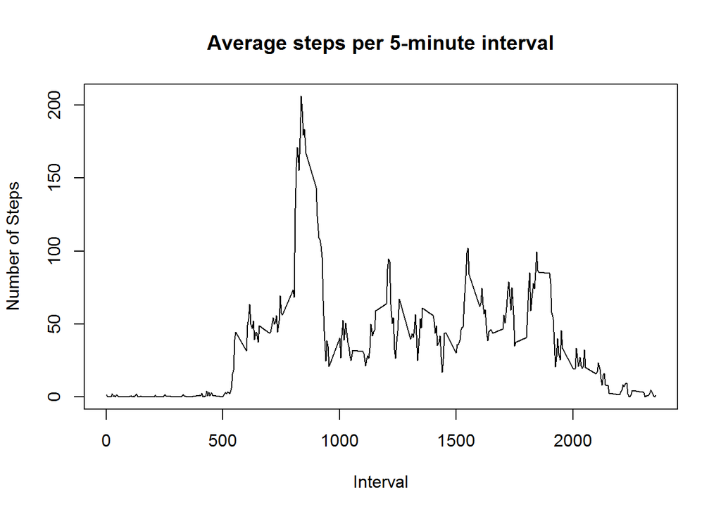

```r
plot(step_5min$interval,step_5min$steps, type="l", main="Average steps per 5-minute interval",ylab="Number of Steps",xlab="Interval")
```

which 5-minute interval during the day has the most steps.

```r
step_5min$interval[which.max(step_5min$steps)]
```

```
## [1] 835
```

# Imputing missing values

Calculate and report the total number of missing values in the dataset(the total number of rows with NAs)

```r
  steps_na<-which(is.na(steps))
  length(steps_na)
```

```
## [1] 2304
```

merging with original data to fill in all of the missing values in the dataset

```r
steps_filled<-merge(steps, step_5min,by="interval")
```

Replace NA values with mean of steps values for that time interval

```r
  steps_na<-which(is.na(steps_filled$steps.x))
  steps_filled$steps.x[steps_na]<-steps_filled$steps.y[steps_na]
```

Make a histogram of the total number of steps taken each day and calculate and report the mean and median total number of steps taken per day.

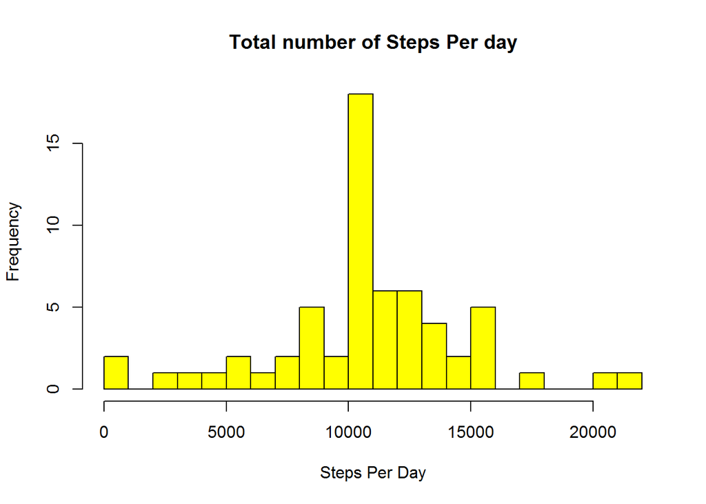

```r
steps_day_new<-aggregate(steps.x~date, data=steps_filled, sum)
hist(steps_day_new$steps.x, breaks=20,main="Total number of Steps Per day", xlab="Steps Per Day", border="black", col="yellow")
```

Calculate the updated mean of the steps per day

```r
mean_steps<-mean(steps_day_new$steps.x)
mean_steps
```

```
## [1] 10766.19
```

Calculate the updated median of the steps per day

```r
med_steps<-median(steps_day_new$steps.x)
med_steps
```

```
## [1] 10766.19
```

# Are there differences in activity patterns between weekdays and weekends?

Create a new factor variable in the dataset with two levels- weekday and weekend

```r
  steps_filled<-merge(steps, step_5min,by="interval")
  steps_filled$steps.x[steps_na]<-steps_filled$steps.y[steps_na]
  steps_filled<-cbind(steps_filled,wkday=weekdays(as.Date(steps_filled$date)))
  steps_filled<-cbind(steps_filled,    day_type="", stringsAsFactors=FALSE)

  for(i in 1:nrow(steps_filled)){
    if(steps_filled$wkday[i] %in% c("Saturday","Sunday"))
      steps_filled$day_type[i]="Weekend"
    else
      steps_filled$day_type[i]="Weekday"
  }
  steps_filled$day_type<-as.factor(steps_filled$day_type)
```

Get average steps per 5-minute interval and week day type

```r
steps_interval_day<-aggregate(steps_filled$steps.x,by=list(steps_filled$interval,steps_filled$day_type),mean)
```

Make a panel plot containing a time series plot of 5-minute interval(x-axis) and the avarage number of steps taken, averaged across all weekday days or weekend days(y-axis).

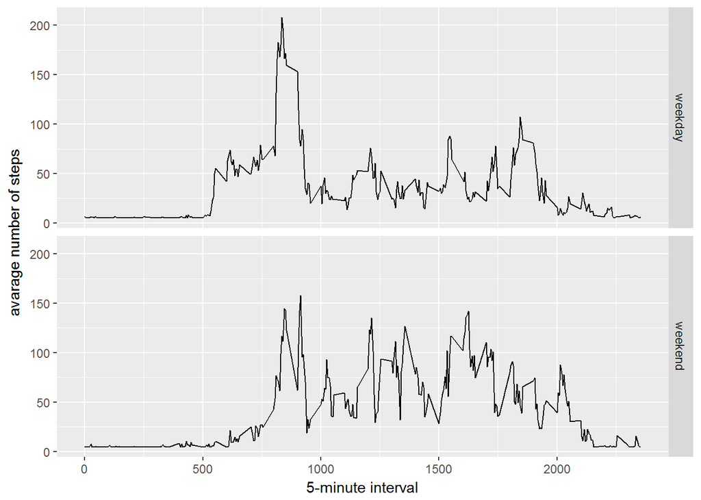

```r
ADI <- steps
ADI$steps <- impute(steps$steps, fun=mean)

stepsByDayImputed <- tapply(ADI$steps, ADI$date, sum)

stepsByDayMeanImputed <- mean(stepsByDayImputed)
stepsByDayMedianImputed <- median(stepsByDayImputed)

ADI$dateType <-  ifelse(as.POSIXlt(ADI$date)$wday %in% c(0,6), 'weekend', 'weekday')


averagedADI <- aggregate(steps ~ interval + dateType, data=ADI, mean)
library(ggplot2)
ggplot(averagedADI, aes(interval, steps)) +
    geom_line() +
    facet_grid(dateType ~ .) +
    xlab("5-minute interval") +
    ylab("avarage number of steps")
```